# Running large databases: PIM

# Introduction

In this report, we try to fit PIM models when $N$ is large. As the estimation procecures uses the set of *pseudo-observations*, the computation time increases exponentially with $n$: $O(n^2)$.

# Data generation

We will generate data according to the normal linear model: $Y_i = \alpha X_i + \varepsilon_i$ with $i=1,...n$. Also, $\varepsilon_i|X_i$ are IID and $N(0, \sigma^2_\varepsilon(X_i))$. The predictor takes values uniformly within $[0.1,u]$ where $u = 1$. For instance, take $\alpha = 5$. Then generating data and fitting the PIM model in R is done through:

```r
# Parameters
n <- 50
u <- 1
alpha <- 5
sigma <- 1
trueBeta <- alpha/(sqrt(2) * sigma)
# Generate predictor
X <- runif(n = n, min = 0.1, max = u)
# Generate data
Y <- alpha*X + rnorm(n = n, mean = 0, sd = sigma)
# PIM package beta parameter
BETAvalue <- try(pim(formula = Y ~ X, link = 'probit', model = 'difference')@coef, silent = TRUE)
data.frame(BETAvalue,trueBeta)
```

|  | BETAvalue | trueBeta |
| --- | --- | --- |
| X | 3.055026 | 3.535534 |

# Increasing N

We take the code from above, and run this while increasing $N$ initially from $10$ to $25.000$.

## Locally

First, we test this locally. The vector $N$ is given by:

```r
n <- round(seq(10,25000,length.out = 25), 0)
n
```

```
 [1]    10  1051  2092  3134  4175  5216  6258  7299  8340  9381 10422 11464 12505 13546 14588 15629 16670 17711 18752 19794
[21] 20835 21876 22918 23959 25000
```

The estimated beta coefficients and time needed to estimate the model for each sample size $N$ are stored in a text file. And plotted below.

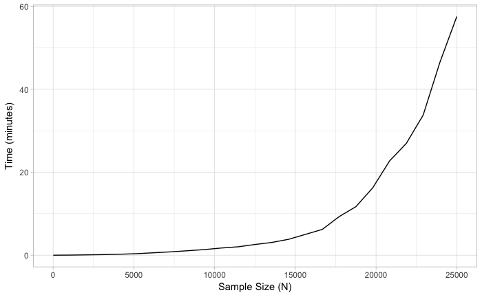

## HPC

We execute the same code on the HPC infrastructure of UGent and iterated for $K = 500$ times. The results are stored externaly in text files caled *beta_N_n_K_k.txt* and *time_N_n_K_k.txt* in which small *n* and small *k* represent the sample size and iteration respectively.

| EstimatedBeta | TrueBeta | SampleSize | TimeInMin |
| --- | --- | --- | --- |
| 4.271203 | 3.535534 | 10 | 0.0005379234 |
| 3.546431 | 3.535534 | 1051 | 0.0253973256 |
| 3.543821 | 3.535534 | 2092 | 0.0845617874 |
| 3.534804 | 3.535534 | 3134 | 0.1882360769 |
| 3.535431 | 3.535534 | 4175 | 0.3400619260 |
| 3.534056 | 3.535534 | 5216 | 0.5492313999 |
| 3.537546 | 3.535534 | 6258 | 0.8752335478 |
| 3.535204 | 3.535534 | 7299 | 1.4030073936 |
| 3.533692 | 3.535534 | 8340 | 2.0160403477 |
| NA | 3.535534 | 9381 | NA |

[output cut: 15 more lines]

We were only able to reliably run the model when $N \leq 8340$. When $N$ was higher, we ran out of memory to solve the estimating equations.